# HW2

Yifan Li

2/10/2018

# Q1

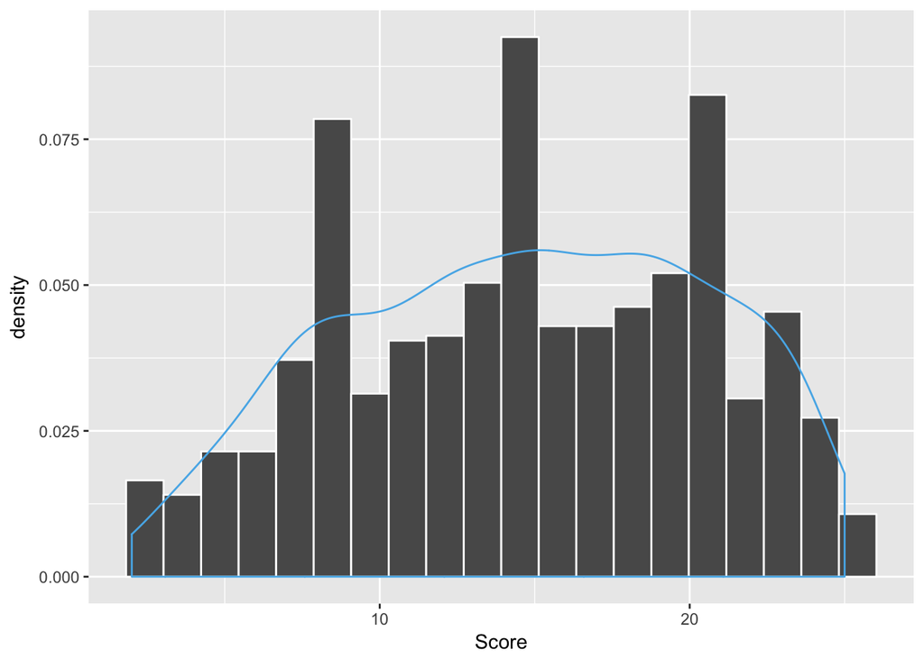

```
## # A tibble: 1 x 5
##    mean median    sd   min   max
##   <dbl>  <dbl> <dbl> <dbl> <dbl>
## 1  14.7   15.0  5.77  2.00  25.0
```

**Scores doesn’t follow the normal distribution. Some values appear more frequently.**

# Q2

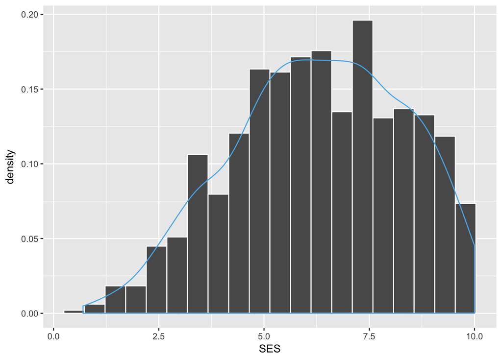

```
## # A tibble: 1 x 5
##    mean median    sd   min   max
##   <dbl>  <dbl> <dbl> <dbl> <dbl>
## 1  6.30   6.40  2.02 0.700  10.0
```

**Values of SES are around 6.4 instead of 5 which means higher values appeals more frequently than lower ones.**

# Q3

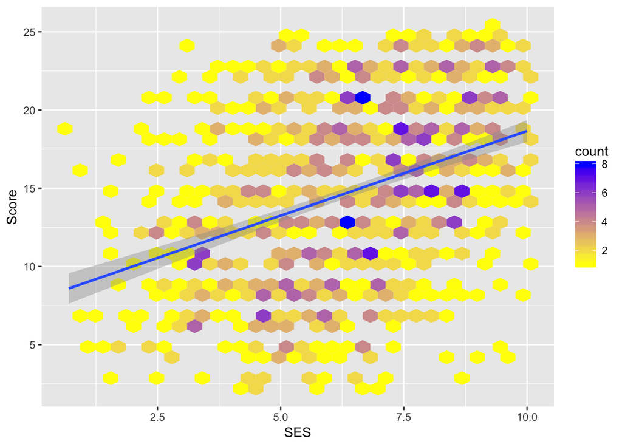

**There seems to be a linear relationship between SES and Score.**

# Q4

```
## # A tibble: 159 x 4
##    School   SES Score Number
##     <int> <dbl> <dbl>  <int>
##  1   1224  5.22 11.3       6
##  2   1288  7.07 17.5       6
##  3   1296  5.10 11.0       6
##  4   1308  7.55 18.2       4
##  5   1317  7.42 16.2       8
##  6   1358  5.72 12.5       6
##  7   1374  6.10  6.50      2
##  8   1433  7.24 19.6       7
##  9   1436  7.61 19.1       9
## 10   1461  7.48 16.7       6
## # ... with 149 more rows
```

**The total number of students are 1000 and schools are 159.**

# Q5

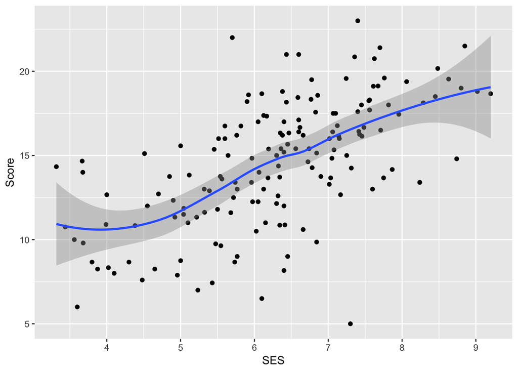

1. Generally speaking, the higher SES, the higher Score.
2. The linear relationship between SES and scores is more signicicant for schools with high SES.

# Q6

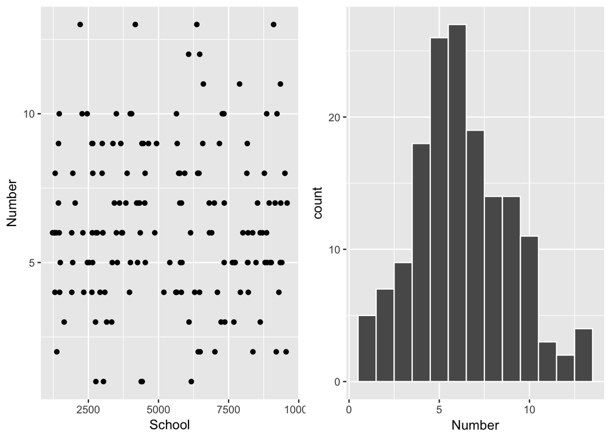

# Q7

```
## # A tibble: 5 x 2
##   index label
##   <chr> <int>
## 1 A      4420
## 2 B      3039
## 3 C      4173
## 4 D      9104
## 5 E      8707
```

# Q8

```
## # A tibble: 4 x 3
##   parameter Estimate      sd
##   <chr>        <dbl>   <dbl>
## 1 sigmaA       1.99  NA
## 2 sigma        4.98  NA
## 3 beta0        9.06   0.592
## 4 beta1        0.877  0.0870
```

$$\begin{aligned}
y_i
&= (\beta_0 + \alpha_{j[i]}) + \beta_1x_i + \epsilon_i\\
&\alpha \sim N(0, \sigma_A)\\
&\epsilon \sim N(0, \sigma)
\end{aligned}$$

# Q9

```
## # A tibble: 4 x 3
##   parameter Estimate     sd
##   <chr>        <dbl>  <dbl>
## 1 sigmaA       2.00  0.261
## 2 sigma        4.99  0.125
## 3 beta0        9.05  0.631
## 4 beta1        0.879 0.0951
```

# Q10

```
## # A tibble: 4 x 3
##   parameter  `2.5%` `97.5%`
##   <chr>       <dbl>   <dbl>
## 1 lmer_beta0  7.84    10.3
## 2 lmer_beta1  0.698    1.06
## 3 stan_beta0  7.84    10.3
## 4 stan_beta1  0.696    1.06
```

**The estimaters are almost the same.**

# Q11

```
## # A tibble: 4 x 3
##   parameter   `2.5%` `97.5%`
##   <chr>        <dbl>   <dbl>
## 1 stan1_beta0  7.84    10.3
## 2 stan1_beta1  0.696    1.06
## 3 stan2_beta0  7.88    10.3
## 4 stan2_beta1  0.701    1.05
```

**The credible regions are almost the same.**

# Q12

```
## # A tibble: 4 x 3
##   parameter   `2.5%` `97.5%`
##   <chr>        <dbl>   <dbl>
## 1 stan1_beta0  7.84    10.3
## 2 stan1_beta1  0.696    1.06
## 3 stan3_beta0  7.75    10.3
## 4 stan3_beta1  0.702    1.08
```

1. The lower bound of intercept in model with Cauchy distribution decrease a bit.
2. The lower bound of slope in model with Cauchy distribution increase a bit.

# Q13

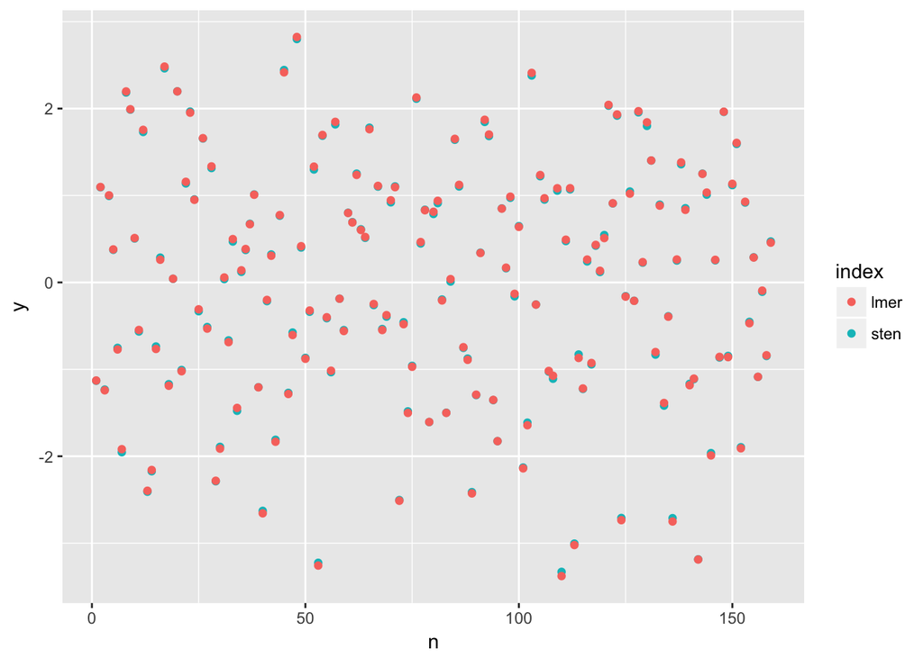

**Almost all the estimated school effects are the same.**

# Q14

```
## # A tibble: 10 x 8
##    index School median_conf lower_conf upper_conf median_pred lower… uppe…
##    <chr> <chr>        <dbl>      <dbl>      <dbl>       <dbl>  <dbl> <dbl>
##  1 lmer  A             14.1       13.3       14.9        15.1   4.58  24.0
##  2 lmer  B             17.2       16.3       18.0        15.6   5.34  24.2
##  3 lmer  C             14.8       13.3       16.2        15.7  12.6   18.8
##  4 lmer  D             17.8       16.4       19.3        16.1  13.0   19.2
##  5 lmer  E             14.9       13.6       16.2        15.7  11.6   19.8
##  6 stan  A             15.1       11.6       18.8        16.2   6.09  27.1
##  7 stan  B             17.1       13.5       20.6        15.4   5.17  25.9
##  8 stan  C             15.1       13.0       17.4        15.8  12.2   19.3
##  9 stan  D             18.6       16.4       20.7        17.2  13.7   20.5
## 10 stan  E             15.5       12.6       18.2        16.1  11.1   21.0
```

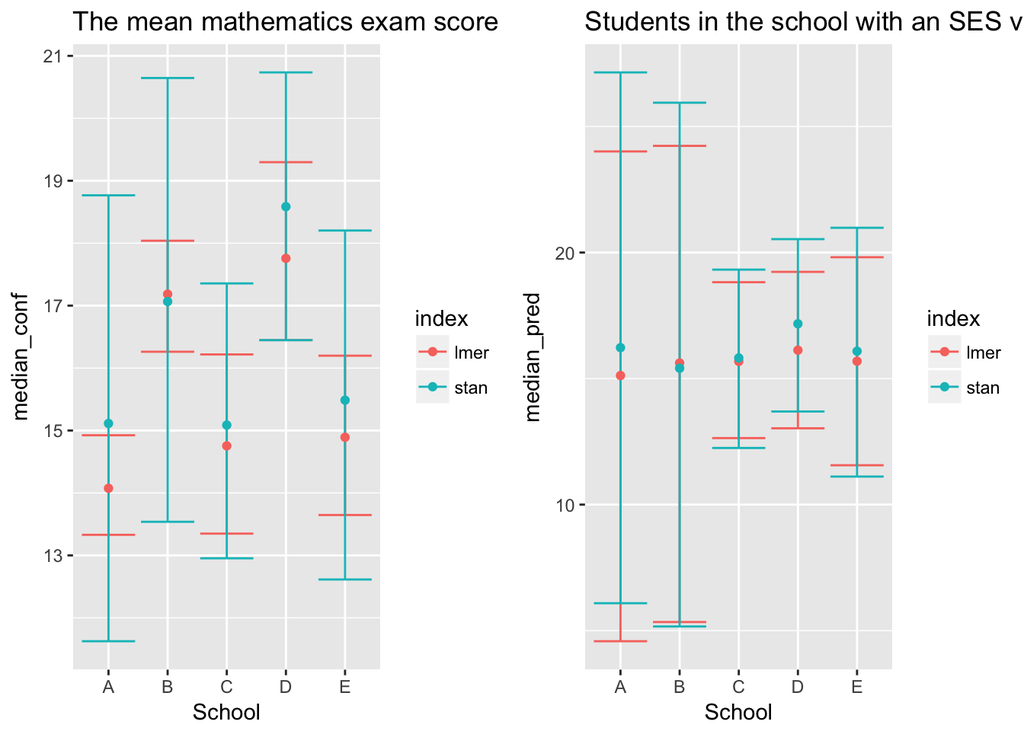

**From the plot, we can see that the confidence intervals of lmer is shorter than stan when predicting the mean score. However, in case of predicting for all students in the school with an SES value of 7, though the confidence intervals of lmer is still shorter, the difference between is small.**

# Q15

```
## # A tibble: 10 x 5
##    index School median_pred lower_pred upper_pred
##    <chr> <chr>        <dbl>      <dbl>      <dbl>
##  1 lmer  A             15.8       5.63       25.8
##  2 lmer  B             15.3       5.25       24.9
##  3 lmer  C             15.7       6.07       25.5
##  4 lmer  D             15.7       5.60       25.3
##  5 lmer  E             15.9       5.73       26.0
##  6 stan  A             15.1      11.6        18.8
##  7 stan  B             17.1      13.5        20.6
##  8 stan  C             15.1      11.4        18.8
##  9 stan  D             18.6      16.1        21.0
## 10 stan  E             15.2      11.6        20.0
```

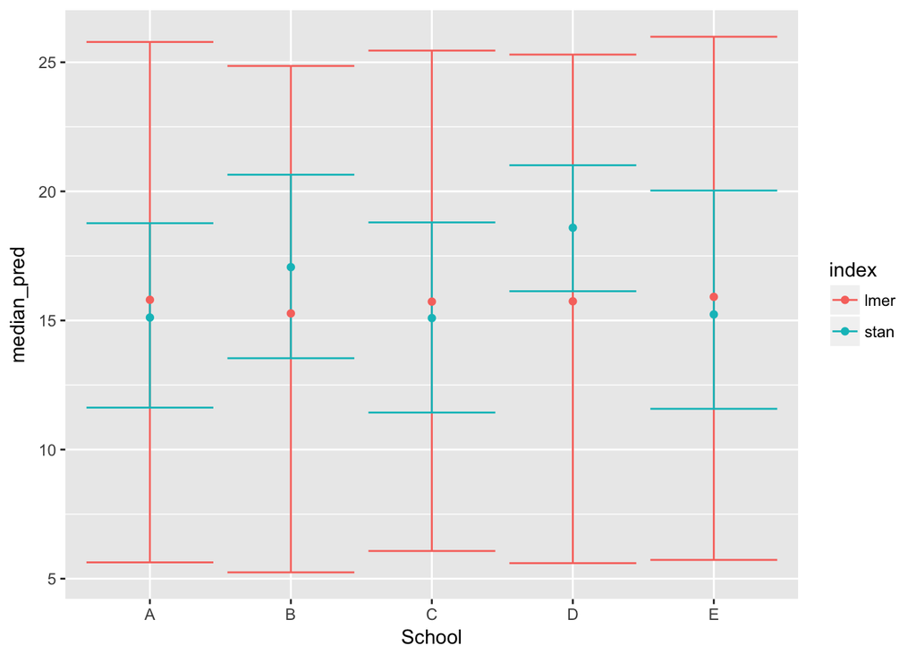

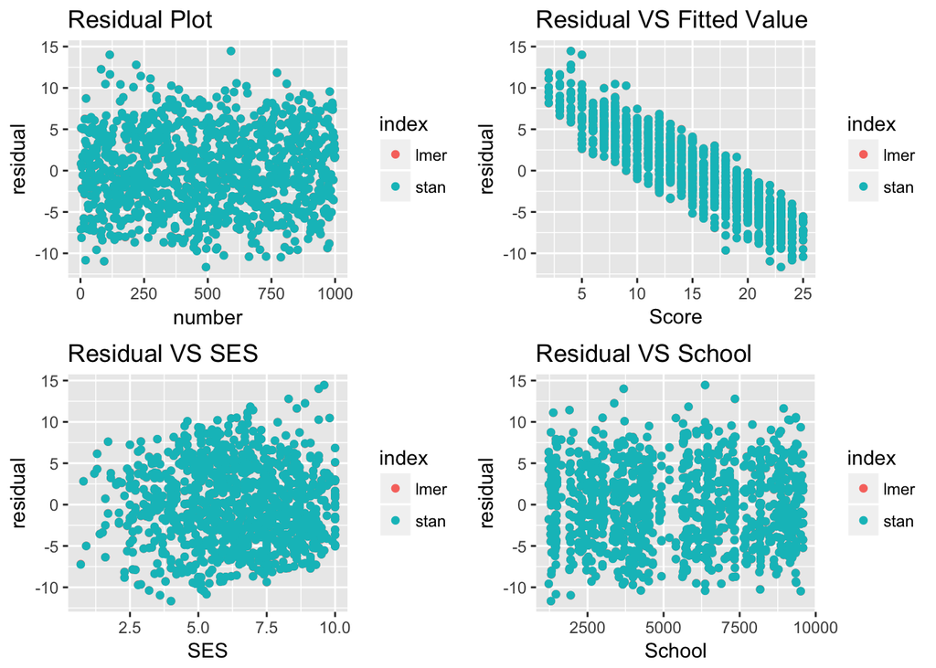

**There exists a linear patterm between residuals and fitted values. For further analysis, I want to fit a linear regression between Score and 1/SES.**